# Tarea-04

## Lauro Reyes Rosas

CU: 214532

Cargamos los paquetes que necesitaremos:

```r
library(tidyverse)
library(nullabor)
```

## Pruebas visuales y Permutación

#### Pruebas de permutación

1. La tabla de datos *Phillies2009* contiene información de la temporada de baseball 2009 para el equipo de Philadelphia *Phillies*, en este ejercicio queremos comparar los strikes (`StrikeOuts`) entre los juegos en casa y de visitante:

```r
df <- read_csv("Phillies2009.csv")
```

1. Realiza un *lineup* donde cada panel muestre un diagrama de caja y brazos para la variable de interés separando los juegos jugados en casa (home) y los juegos jugados fuera (away). ¿Puedes localizar los datos verdaderos entre los nulos?

```r
location_tbl <- df %>%
  select(StrikeOuts, Location)
set.seed(4)
rep <- lineup(null_permute("Location"), location_tbl, n = 20)
```

```
decrypt("nsW7 Ykjk l3 gCPljlC3 4F")
```

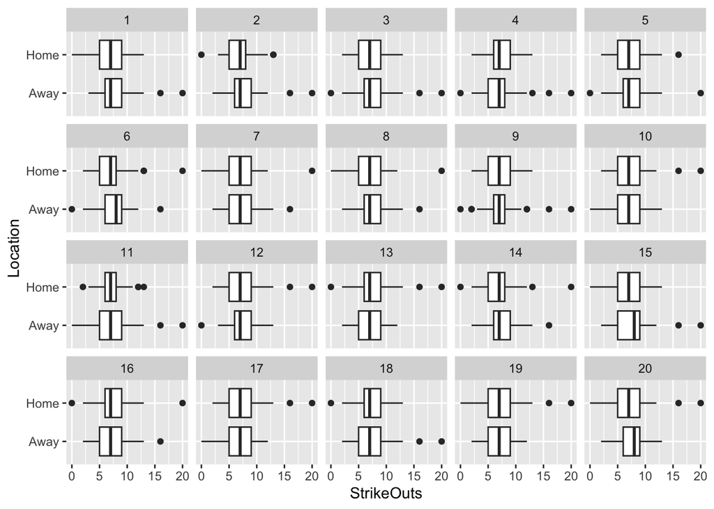

```r
ggplot(rep, aes(y=Location, x=StrikeOuts)) +
  geom_boxplot() + facet_wrap(~.sample)
```

R: Los datos verdaderos me parece que son la iteración 9

- Calcula el promedio de strikes por juego en cada grupo (donde grupo se define por Location).

```r
prom_strikeouts<- df %>%
  group_by(Location) %>%
  summarise(prom=mean(StrikeOuts)) %>%
  ungroup() %>%
  pivot_wider(names_from = Location, values_from = prom) %>%
  mutate(diferencia = Away-Home)
prom_strikeouts
```

```
# A tibble: 1 × 3
   Away  Home diferencia
  <dbl> <dbl>      <dbl>
1  7.31  6.95      0.358
```

1. Realiza una prueba de permutación para la diferencia de las medias. Grafica la distribución de referencia y calcula el valor *p* de dos colas.

```r
set.seed(4)
perms_strikeout <- lineup(null_permute("StrikeOuts"),
                        df%>%select(Location,StrikeOuts),
                        n = 5000)
```

```
decrypt("nsW7 Ykjk l3 gCPljlC3 KJT")
```

```r
resumen <- perms_strikeout %>%
  group_by(.sample) %>%
  summarise(dif_home_away = mean(StrikeOuts[Location == "Away"]) - mean(StrikeOuts[Location == "Home"]))

g_1 <- ggplot(resumen, aes(sample = dif_home_away)) + geom_qq(distribution = stats::qunif)  +
  xlab("f") + ylab("diferencia") + labs(subtitle = "Distribución nula o de referencia") +
  geom_hline(yintercept = prom_strikeouts$diferencia, colour = "red") +
  annotate("text", x = 0.35, y = prom_strikeouts$diferencia - 0.03, label = "diferencia observada", colour = "red")

g_2 <- ggplot(resumen, aes(y=dif_home_away)) +
  geom_histogram() +
  geom_hline(yintercept = prom_strikeouts$diferencia,
             linetype ='dashed', color='red')
```

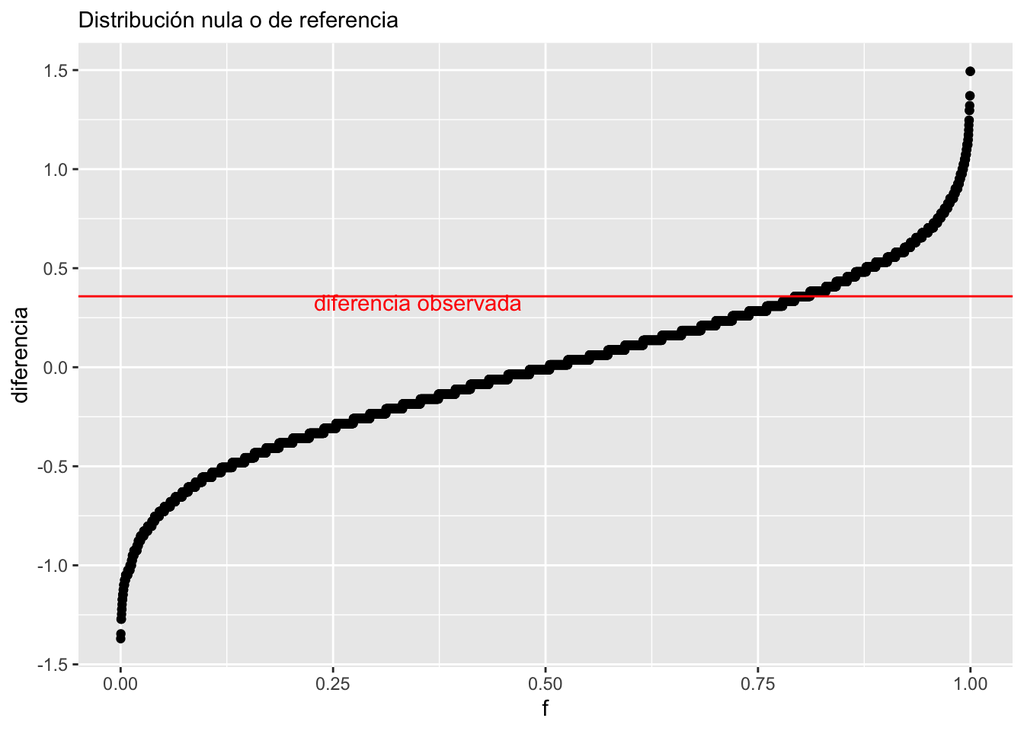

```r
g_1
```

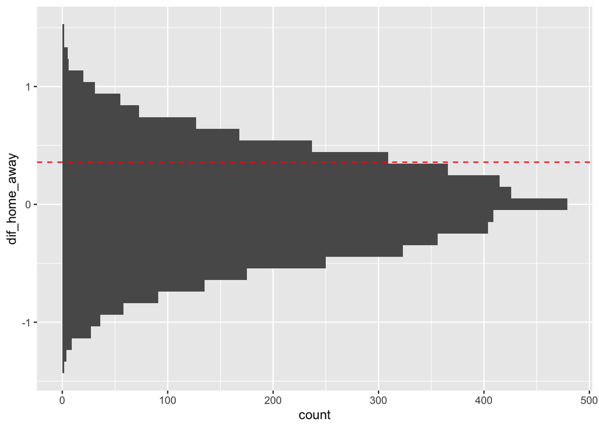

```r
g_2
```

```r
dist_perm <- ecdf(resumen$dif_home_away)
valor_p <- 2 * min(dist_perm(prom_strikeouts$diferencia),
                   (1 - dist_perm(prom_strikeouts$diferencia)))
valor_p
```

```
[1] 0.3776
```

## Pruebas pareadas

En este ejemplo buscamos comparar la diferencia entre dos medicinas para dormir.

- ID es el identificador de paciente, group el identificador de la medicina, y extra son las horas extras de sueño.

- Examina los datos.

```r
sleep
```

```
   extra group ID
1    0.7     1  1
2   -1.6     1  2
3   -0.2     1  3
4   -1.2     1  4
5   -0.1     1  5
6    3.4     1  6
7    3.7     1  7
8    0.8     1  8
9    0.0     1  9
10   2.0     1 10
11   1.9     2  1
12   0.8     2  2
13   1.1     2  3
14   0.1     2  4
15  -0.1     2  5
16   4.4     2  6
17   5.5     2  7
18   1.6     2  8
19   4.6     2  9
20   3.4     2 10
```

La pregunta de interés es si una medicina es mejor que otra para prolongar el sueño. Nótese que en este caso, no tenemos grupos, sino mediciones repetidas.

- Escribe la hipótesis nula.
- Nuestra estadística de interés es media de las diferencias entre las medicinas. Calcula la diferencia observada.
- Hay variación entre los pacientes. ¿Tenemos evidencia para rechazar que son iguales? ¿Cómo hacemos nuestra distribución de referencia?
- Haz una gráfica de la distribución de referencia y grafica encima el valor observado en los datos originales.
- Calcula el valor p (justifica porque a una o dos colas).

## Valores-*p (opcional)*

Cuando usamos simulación para pruebas de permutación, el valor-*p* de una cola se puede calcular como

$$\hat{P}=(X+1)/(N+1)$$
donde $X$ es el número de estadísticas de prueba remuestreadas que son al menos tan extremas como la observada. Supongamos que el verdadero valor *p* (si pudiéramos hacer todas las permutaciones de manera exhaustiva) es $p$

- ¿Cuál es la varianza de $\hat{P}$?

- ¿Cuál es la varianza de $\hat{P_2}$ para la prueba de dos lados? (suponiendo que $p$ no es cercano a $0.5$, donde $p$ es el verdadero valor *p* para la prueba de una cola).

## Pruebas de hipótesis *(opcional)*

Ve el video [Is Most Published Research Wrong?](https://www.youtube.com/watch?v=42QuXLucH3Q)